# Exercise 1: Bayesian multiple shooting for latent ODEs (9 points)

The goal of this exercise is to observe firsthand the training instability for long trajectories that was discussed in the lecture. Specifically, we will replicate the experiment shown in Figure 1 and Appendix A of [Iakovlev et al. (2023)](https://arxiv.org/abs/2210.03466). We start by training a regular NODE with the structure given below

$ \begin{align} x_i &\sim p(x_i) \\ θ_{dyn} &\sim p(\theta_{dyn}) \\ x_i &= ODEsolve(x_i, t_i, t_i, \theta_{dyn}), i > 1 \\ y_i \mid x_i &\sim p(y_i \mid g(x_i, \theta_{dec})) \\ \end{align} $

where $y_i$ are observations, $x_i$ are latent representations of said observations, $\theta_{dyn}$ is the dynamics function, and $\theta_{dec}$ is the decoder function. In this exercise, we will be working with a 2 state data, which means we can work in the state space directly, no need for a latent space. In other words, our decoder $\theta_{dec}$ is the identity function.

```python
# run this once
#pip install torchdiffeq
```

```python
import torch.optim as optim

# Load the data
import torch
import torch.nn as nn
import numpy as np
from torch.utils.data import DataLoader, Dataset, TensorDataset
import random
from torchdiffeq import odeint

import matplotlib.pyplot as plt

from math import sqrt

# Set random seeds for reproducibility
torch.manual_seed(42)
np.random.seed(42)
random.seed(42)
```

## Data Generation

We will be working with simple sequence data representing the motion of a pendulum through its angle and angular velocity. Note that because our data is simple, we will not be using a **latent** ODE in this assignment; instead our model will be operating in the state space directly. In the more complex experiments presented in Iakovlev et al. (2023), an encoder/decoder structure is needed to reduce the dimensionality of the data before modelling the system's dynamics in the latent space.

Run the code in the cells below to generate a single sequence of pendulum motion (angle and angular velocity). Check that the plot looks like figure 14 in Iakovlev et al. (2023).

```python
def generate_pendulum_data(t_max=3.0):
    """
    Generate a single 2D pendulum state trajectory [angle, velocity] using torchdiffeq solver,
    with data sampled every 0.1 seconds as specified in the paper.

    Args:
        t_max: End time (seconds)

    Returns:
        data: Tensor of shape [seq_length, 2]
        times: Tensor of shape [seq_length]
    """
    # Time points every 0.1 seconds, as specified in the paper
    t = torch.arange(0, t_max + 0.05, 0.1)  # Adding 0.05 for numerical stability

    # Initial conditions as per the paper (90 degrees position, 0 velocity)
    angle = torch.tensor(90.0 * np.pi/180.0, dtype=torch.float32)  # 90 degrees in radians
    velocity = torch.tensor(0.0, dtype=torch.float32)              # Initial velocity is zero
    initial_state = torch.stack([angle, velocity])

    # Pendulum ODE function: dy/dt = [velocity, -g*sin(angle)]
    def pendulum_dynamics(t, state):
        angle, velocity = state[0], state[1]
        dangle_dt = velocity
        dvelocity_dt = -9.81 * torch.sin(angle)
        return torch.stack([dangle_dt, dvelocity_dt])

    # Solve ODE using torchdiffeq with dopri5 solver (same as paper)
    trajectory = odeint(
        pendulum_dynamics,
        initial_state,
        t,
        method='dopri5',  # Same solver used in the paper
        rtol=1e-5,
        atol=1e-5
    )

    # trajectory shape: [seq_length, 2]
    return trajectory, t

# Function to visualize a trajectory
def plot_pendulum_trajectory(trajectory, time):
    """
    Plot a pendulum trajectory in phase space and as time series.

    Args:
        trajectory: Shape [seq_length, 2] with angle and velocity
        time: Shape [seq_length] with time points
    """
    plt.figure(figsize=(12, 5))

    # Phase space plot
    plt.subplot(1, 2, 1)
    plt.plot(trajectory[:, 0], trajectory[:, 1])
    plt.xlabel('Angle (θ)')
    plt.ylabel('Angular Velocity (ω)')
    plt.title('Phase Space')
    plt.grid(True)

    # Time series plot
    plt.subplot(1, 2, 2)
    plt.plot(time, trajectory[:, 0], label='Angle (θ)')
    plt.plot(time, trajectory[:, 1], label='Angular Velocity (ω)')
    plt.xlabel('Time')
    plt.ylabel('Value')
    plt.title('Time Series')
    plt.legend()
    plt.grid(True)

    plt.tight_layout()
    plt.show()
```

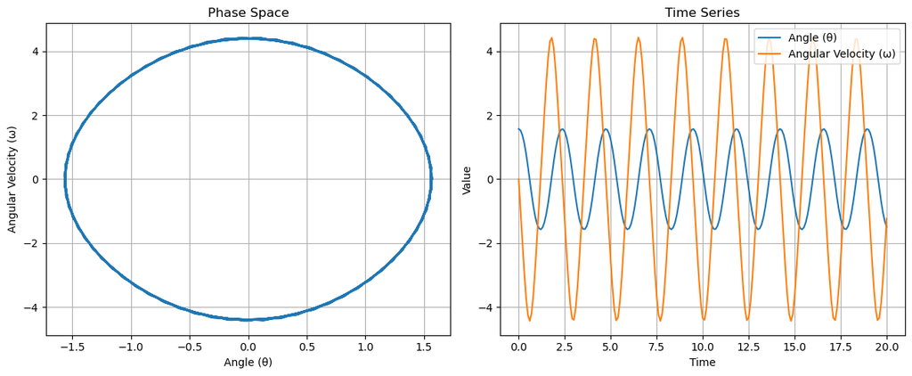

```python
data, times = generate_pendulum_data(t_max=20.0)
plot_pendulum_trajectory(trajectory=data, time=times)
```

## Dynamics function (1 point)

We use a second-order dynamics function as explained in Appendix E.4.1 in Iakovlev et al. (2023). The function takes as input the position and the velocity of the pendulum and approximates their respective derivatives. The function itself is an MLP with 2 hidden layers, with hidden_dim=16 and Tanh non-linearity.

Remember that latent dimension here is equal to 1, since we are working in the state space directly because our data is simple.

**Student's answer(Top)**

```python
# Second-order dynamics model as described in Appendix A
class DynamicsFunction(nn.Module):
    def __init__(self, latent_dim, hidden_dim=16):
        super().__init__()
        # implement "an MLP with two hidden layers of size 16"
        # YOUR CODE HERE
        self.net = nn.Sequential(
            nn.Linear(latent_dim, hidden_dim),
            nn.Tanh(),
            nn.Linear(hidden_dim, hidden_dim),
            nn.Tanh(),
            nn.Linear(hidden_dim, latent_dim),
        )
        #raise NotImplementedError()

    def forward(self, x):
        # the function learns the derivative of the position and velocity
        # YOUR CODE HERE
        batch_size, latent_dim = x.shape
        out = self.net(x)
        idx = (int)(latent_dim/2)
        out[:, :idx] = x[:, idx:]
        return out
        #raise NotImplementedError()
```

**Comments:**

No need to make the NN output the velocity then discard it, it's redundant and might cause learning instabilities.

```python
def test_dynamics_function_visible():
    """Test the basic structure and functionality of DynamicsFunction."""
    import torch
    import torch.nn as nn

    # Test with small dimensions for simplicity
    latent_dim = 4
    model = DynamicsFunction(latent_dim)

    # Check basic structure
    assert isinstance(model, nn.Module), "DynamicsFunction should inherit from nn.Module"
    assert hasattr(model, 'net'), "DynamicsFunction should have a 'net' attribute"
    assert isinstance(model.net, nn.Sequential), "The network should be implemented as nn.Sequential"

    # Check that the model has the right number of layers
    layers = [module for module in model.net if isinstance(module, nn.Linear)]
    assert len(layers) == 3, "The network should have 3 linear layers (input->hidden, hidden->hidden, hidden->output)"

    # Test forward pass functionality
    batch_size = 2
    x = torch.randn(batch_size, latent_dim)
    output = model(x)

    # Check output shape
    assert output.shape == x.shape, f"Output shape {output.shape} should match input shape {x.shape}"

    # Check that the output contains the velocity unchanged in the first half
    velocity_input = x[:, latent_dim//2:]
    velocity_output = output[:, :latent_dim//2]
    assert torch.allclose(velocity_input, velocity_output), "The first half of the output should be the velocity from the input"

    print("All visible tests passed!")
test_dynamics_function_visible()
```

```
All visible tests passed!
```

**Grade cell: `cell-70a307dbe1687c2d` Score: 0.5 / 1.0 (Top)**

```python
### BEGIN HIDDEN TESTS
def test_dynamics_function_visible():
    """Test the basic structure and functionality of DynamicsFunction."""
    import torch
    import torch.nn as nn

    # Test with small dimensions for simplicity
    latent_dim = 4
    model = DynamicsFunction(latent_dim)

    # Check basic structure
    assert isinstance(model, nn.Module), "DynamicsFunction should inherit from nn.Module"
    assert hasattr(model, 'net'), "DynamicsFunction should have a 'net' attribute"
    assert isinstance(model.net, nn.Sequential), "The network should be implemented as nn.Sequential"

    # Check that the model has the right number of layers
    layers = [module for module in model.net if isinstance(module, nn.Linear)]
    assert len(layers) == 3, "The network should have 3 linear layers (input->hidden, hidden->hidden, hidden->output)"

    # Test forward pass functionality
    batch_size = 2
    x = torch.randn(batch_size, latent_dim)
    output = model(x)

    # Check output shape
    assert output.shape == x.shape, f"Output shape {output.shape} should match input shape {x.shape}"

    # Check that the output contains the velocity unchanged in the first half
    velocity_input = x[:, latent_dim//2:]
    velocity_output = output[:, :latent_dim//2]
    assert torch.allclose(velocity_input, velocity_output), "The first half of the output should be the velocity from the input"

    print("All visible tests passed!")
test_dynamics_function_visible()

def test_dynamics_function_hidden():
    """Hidden test for more detailed evaluation of DynamicsFunction."""
    import torch
    import torch.nn as nn
    import numpy as np

    # Test various latent dimensions
    for latent_dim in [2, 4, 6, 10]:
        model = DynamicsFunction(latent_dim)

        # Check that hidden_dim is set correctly
        hidden_layers = [layer for layer in model.net if isinstance(layer, nn.Linear)]
        assert hidden_layers[0].out_features == 16, "First hidden layer should have 16 units"
        assert hidden_layers[1].out_features == 16, "Second hidden layer should have 16 units"

        # Check activation functions
        activations = [module for module in model.net if isinstance(module, nn.Tanh)]
        assert len(activations) == 2, "There should be exactly 2 Tanh activation functions"

        # Check output layer dimension
        assert hidden_layers[2].out_features == latent_dim // 2, f"Output layer should have {latent_dim // 2} units for acceleration"

        # Test with different batch dimensions to ensure proper broadcasting
        for shape in [(latent_dim,), (3, latent_dim), (2, 5, latent_dim)]:
            x = torch.randn(*shape)
            output = model(x)

            # Check that output shape matches input shape
            assert output.shape == x.shape, f"Output shape {output.shape} should match input shape {x.shape} for arbitrary batching"

            # Verify that position derivatives are velocities from input
            pos_dim = latent_dim // 2
            velocity_input = x[..., pos_dim:]
            velocity_output = output[..., :pos_dim]
            assert torch.allclose(velocity_input, velocity_output), "Velocity in output should match velocity from input"

            # Check that acceleration values are produced by the network
            accel_output = output[..., pos_dim:]
            accel_from_net = model.net(x)
            assert torch.allclose(accel_output, accel_from_net), "Acceleration should come from the neural network"

    # Test with different hidden dimensions
    custom_hidden_dim = 32
    model = DynamicsFunction(latent_dim=6, hidden_dim=custom_hidden_dim)
    hidden_layers = [layer for layer in model.net if isinstance(layer, nn.Linear)]
    assert hidden_layers[0].out_features == custom_hidden_dim, f"Hidden dimension parameter should be respected, got {hidden_layers[0].out_features} expected {custom_hidden_dim}"

    # Test gradient flow
    latent_dim = 4
    model = DynamicsFunction(latent_dim)
    x = torch.randn(2, latent_dim, requires_grad=True)
    output = model(x)
    loss = output.sum()
    loss.backward()

    # Check that gradients flow through the model
    for name, param in model.named_parameters():
        assert param.grad is not None, f"Gradient for {name} is None"
        assert not torch.allclose(param.grad, torch.zeros_like(param.grad)), f"Gradient for {name} is all zeros"

    print("All hidden tests passed!")
test_dynamics_function_hidden()
### END HIDDEN TESTS
```

```
All visible tests passed!
```

```
---------------------------------------------------------------------------
AssertionError                            Traceback (most recent call last)
Cell In[7], line 97
     94         assert not torch.allclose(param.grad, torch.zeros_like(param.grad)), f"Gradient for {name} is all zeros"
     96     print("All hidden tests passed!")
---> 97 test_dynamics_function_hidden()
     98 ### END HIDDEN TESTS

Cell In[7], line 56, in test_dynamics_function_hidden()
     53 assert len(activations) == 2, "There should be exactly 2 Tanh activation functions"
     55 # Check output layer dimension
---> 56 assert hidden_layers[2].out_features == latent_dim // 2, f"Output layer should have {latent_dim // 2} units for acceleration"
     58 # Test with different batch dimensions to ensure proper broadcasting
     59 for shape in [(latent_dim,), (3, latent_dim), (2, 5, latent_dim)]:

AssertionError: Output layer should have 1 units for acceleration
```

## Regular Latent NODE (2 point)

Now we need to implement a regular latent ODE model, to show the behavior presented in Figure 1 in Iakovlev et al. (2023).

1. We want to learn both the parameters of the dynamics functio and the initial state of the sequence.
2. In the forward step, the model integrates the dynamics function (defined earlier) to predict both the angle and the angular velocity of the pendulum. You can use torchdiffeq's odeint() to perform the integration with the following parameters: dopri5 solver, and rtol=atol=1e-5. (1 point)
3. The model uses MSE loss to compare the predicted and true pendulum angles (note: angles alone, without velocity). (1 point)

Finish implementing the class functions accordingly.

**Student's answer(Top)**

```python
# Neural ODE model (simplified for Figure 1 experiment)
class LatentNode(nn.Module):
    def __init__(self, latent_dim=2):
        super().__init__()
        self.latent_dim = latent_dim * 2  # x2 for position and velocity

        # Dynamics function
        # YOUR CODE HERE
        self.dynamics_func = DynamicsFunction(self.latent_dim)
        self.func_wrapper = nn.Module()
        self.func_wrapper.forward = lambda t,x : self.dynamics_func(x.unsqueeze(0)).squeeze(0)
        self.initial_state = nn.Parameter(torch.randn(self.latent_dim), requires_grad=True)

        #raise NotImplementedError()

    def forward(self, times):
        # Use initial state
        # YOUR CODE HERE
        y_pred = odeint(func=self.func_wrapper, y0 = self.initial_state, t = times, method='dopri5', rtol=1e-5, atol=1e-5)
        y_pred = y_pred.reshape(times.shape[0], -1, self.latent_dim)

        return y_pred
        #raise NotImplementedError()

    def compute_loss(self, y_true, times):
        """Compute MSE loss as used in Figure 1 experiment"""
        # YOUR CODE HERE
        #print('y_true: ', y_true.shape)
        #print('times: ', times.shape)
        y_pred = self.forward(times)
        #print('y_pred: ', y_pred.shape)
        y_pred = y_pred[:, :, :self.latent_dim//2].squeeze(1)
        #print('y_pred: ', y_pred.shape)
        loss = torch.nn.functional.mse_loss(y_true, y_pred)
        return loss
        #raise NotImplementedError()
```

**Comments:**

you should only take the angle from y_true as well

**Grade cell: `cell-4e5e363b39195eae` Score: 1.0 / 2.0 (Top)**

```python
def test_latent_node_visible():
    """Test the basic structure and functionality of LatentNode."""
    import torch
    import torch.nn as nn
    from torchdiffeq import odeint

    # Initialize model with small latent dimension
    latent_dim = 1  # This means actual dim will be 2 (position + velocity)
    model = LatentNode(latent_dim)

    # Check basic structure
    assert isinstance(model, nn.Module), "LatentNode should inherit from nn.Module"
    assert hasattr(model, 'dynamics_func'), "LatentNode should have a 'dynamics_func' attribute"
    assert isinstance(model.dynamics_func, DynamicsFunction), "dynamics_func should be an instance of DynamicsFunction"
    assert hasattr(model, 'initial_state'), "LatentNode should have an 'initial_state' attribute"
    assert isinstance(model.initial_state, nn.Parameter), "initial_state should be a torch Parameter"
    assert model.initial_state.shape == (latent_dim * 2,), f"initial_state should have shape ({latent_dim * 2},)"

    # Test forward pass
    times = torch.linspace(0, 1, 10)
    trajectory = model(times)

    # Check output shape [time_steps, batch_size, latent_dim*2]
    expected_shape = (len(times), 1, latent_dim * 2)
    assert trajectory.shape == expected_shape, f"Output shape {trajectory.shape} should match {expected_shape}"

    # Test compute_loss method
    y_true = torch.sin(times.unsqueeze(1))  # Simple sine wave as ground truth
    loss = model.compute_loss(y_true, times)

    # Check that loss is a scalar
    assert loss.ndim == 0, "Loss should be a scalar"
    assert not torch.isnan(loss), "Loss should not be NaN"
    assert not torch.isinf(loss), "Loss should not be infinite"

    print("All visible tests passed!")

test_latent_node_visible()

### BEGIN HIDDEN TESTS
def test_latent_node_visible():
    """Test the basic structure and functionality of LatentNode."""
    import torch
    import torch.nn as nn
    from torchdiffeq import odeint

    # Initialize model with small latent dimension
    latent_dim = 1  # This means actual dim will be 2 (position + velocity)
    model = LatentNode(latent_dim)

    # Check basic structure
    assert isinstance(model, nn.Module), "LatentNode should inherit from nn.Module"
    assert hasattr(model, 'dynamics_func'), "LatentNode should have a 'dynamics_func' attribute"
    assert isinstance(model.dynamics_func, DynamicsFunction), "dynamics_func should be an instance of DynamicsFunction"
    assert hasattr(model, 'initial_state'), "LatentNode should have an 'initial_state' attribute"
    assert isinstance(model.initial_state, nn.Parameter), "initial_state should be a torch Parameter"
    assert model.initial_state.shape == (latent_dim * 2,), f"initial_state should have shape ({latent_dim * 2},)"

    # Test forward pass
    times = torch.linspace(0, 1, 10)
    trajectory = model(times)

    # Check output shape [time_steps, batch_size, latent_dim*2]
    expected_shape = (len(times), 1, latent_dim * 2)
    assert trajectory.shape == expected_shape, f"Output shape {trajectory.shape} should match {expected_shape}"

    # Test compute_loss method
    y_true = torch.sin(times.unsqueeze(1))  # Simple sine wave as ground truth
    loss = model.compute_loss(y_true, times)

    # Check that loss is a scalar
    assert loss.ndim == 0, "Loss should be a scalar"
    assert not torch.isnan(loss), "Loss should not be NaN"
    assert not torch.isinf(loss), "Loss should not be infinite"

    print("All visible tests passed!")

test_latent_node_visible()

def test_latent_node_hidden():
    """Hidden test for more detailed evaluation of LatentNode."""
    import torch
    import torch.nn as nn
    from torchdiffeq import odeint
    import numpy as np

    # Test with different latent dimensions
    for latent_dim in [1, 2, 4]:
        model = LatentNode(latent_dim)

        # Check that dynamics function is properly initialized
        assert model.latent_dim == latent_dim * 2, f"Latent dimension should be doubled internally for position+velocity"
        assert model.dynamics_func.latent_dim == latent_dim * 2, "Dynamics function should have the correct latent dimension"

        # Verify initial state parameter
        #assert model.initial_state.requires_grad, "Initial state should have requires_grad=True"
        assert model.initial_state.shape == (latent_dim * 2,), f"Initial state shape should be ({latent_dim * 2},)"

        # Test ODE solver integration
        times = torch.linspace(0, 2, 20)

        # Test actual integration
        trajectory = model(times)
        assert trajectory.shape == (len(times), 1, latent_dim * 2), "Trajectory shape should match (time_steps, batch_size, state_dim)"

        # Test compute_loss with different ground truth shapes
        batch_size = 3
        y_true = torch.randn(len(times), batch_size, 1)  # Only position component

        # Make sure the model can handle batched inputs
        x0_batch = model.initial_state.unsqueeze(0).expand(batch_size, -1)

    # Test with actual dynamics - simple pendulum
    class PendulumDynamics(nn.Module):
        def __init__(self):
            super().__init__()
            self.g = nn.Parameter(torch.tensor(9.8))  # Gravity
            self.latent_dim = 2

        def forward(self, x):
            # Simple pendulum: θ'' = -g*sin(θ)
            theta = x[..., 0:1]
            omega = x[..., 1:2]

            dtheta = omega
            domega = -self.g * torch.sin(theta)

            return torch.cat([dtheta, domega], dim=-1)

    # Create a test model with pendulum dynamics
    model = LatentNode(latent_dim=1)
    model.dynamics_func = PendulumDynamics()

    # Set initial condition to [pi/4, 0] (pendulum at 45 degrees with zero velocity)
    model.initial_state = nn.Parameter(torch.tensor([np.pi/4, 0.0]))

    # Simulate for 1 second
    times = torch.linspace(0, 1, 50)
    trajectory = model(times)

    # Check that trajectory has the right shape
    assert trajectory.shape == (50, 1, 2), f"Trajectory shape should be (50, 1, 2), got {trajectory.shape}"

    # Test compute_loss with simulated data
    # Generate some ground truth data
    y_true = torch.cos(times).unsqueeze(-1).unsqueeze(-1)  # Simple cosine as "position"
    loss = model.compute_loss(y_true, times)

    # Check that loss calculation focuses on the position component
    y_pred = model(times)
    expected_loss = torch.mean((y_pred[..., 0] - y_true[..., 0])**2)
    assert torch.allclose(loss, expected_loss), "Loss should compute MSE between predicted and true positions"

    print("All hidden tests passed!")
test_latent_node_hidden()
### END HIDDEN TESTS
```

```
All visible tests passed!
All visible tests passed!
```

```
---------------------------------------------------------------------------
AttributeError                            Traceback (most recent call last)
Cell In[9], line 155
    152     assert torch.allclose(loss, expected_loss), "Loss should compute MSE between predicted and true positions"
    154     print("All hidden tests passed!")
--> 155 test_latent_node_hidden()
    156 ### END HIDDEN TESTS

Cell In[9], line 93, in test_latent_node_hidden()
     91 # Check that dynamics function is properly initialized
     92 assert model.latent_dim == latent_dim * 2, f"Latent dimension should be doubled internally for position+velocity"
---> 93 assert model.dynamics_func.latent_dim == latent_dim * 2, "Dynamics function should have the correct latent dimension"
     95 # Verify initial state parameter
     96 #assert model.initial_state.requires_grad, "Initial state should have requires_grad=True"
     97 assert model.initial_state.shape == (latent_dim * 2,), f"Initial state shape should be ({latent_dim * 2},)"

File /opt/software/lib/python3.10/site-packages/torch/nn/modules/module.py:1695, in Module.__getattr__(self, name)
   1693     if name in modules:
   1694         return modules[name]
-> 1695 raise AttributeError(f"'{type(self).__name__}' object has no attribute '{name}'")

AttributeError: 'DynamicsFunction' object has no attribute 'latent_dim'
```

## Training and visualizing the loss (1 point)

Complete the code below to train the Neural ODE model defined above.

1. Implement the Adam optimizer with an ExponentialLR scheduler that decreases the learning rate from 3e-4 to 1e-5.
2. Following the paper's methodology, begin training with only the first 10 points of the sequence, then double the 3. sequence length every iterations_per_length iterations.
3. Track and store appropriate metrics during training to reproduce the visualization at the end.

Your implementation should generate a loss curve similar to Figure 1 in the paper, demonstrating:

1. Convergence for short sequences (length < 10)
2. Characteristic peaks after each sequence length increase
3. Failure to converge for sufficiently long sequences

Note: The provided code is configured to train for 100 epochs, whereas the paper reports 3000 iterations per sequence length. Feel free to extend the training duration if needed, but be aware that longer training will significantly increase computation time, especially without GPU acceleration.

**Student's answer(Top)**

```python
def train_and_visualize_model_instability(
    model,
    data,
    times,
    iterations_per_length=3000,
    initial_length=10,
    print_every=100,
    visualize=False
):
    """
    Train the model on sequences of increasing length to demonstrate instability
    as shown in Figure 1 of the paper.
    """
    # Initialize storage for losses and converged parameters
    all_losses = []

    # Start with short sequence and double length until we reach full trajectory
    seq_len = initial_length
    seq_lengths = []

    # Calculate maximum length
    max_length = len(times)

    # For plotting - create continuous x-axis for iterations
    cumulative_iterations = []
    current_iteration = 0

    # YOUR CODE HERE
    initial_lr = 3e-4
    final_lr = 1e-5

    num_seq_lengths = np.floor(np.log2(max_length / initial_length)) + 1
    total_iterations = num_seq_lengths * iterations_per_length
    gamma = (final_lr / initial_lr) ** (1 / total_iterations)
    optimizer = torch.optim.Adam(model.parameters(), lr = initial_lr)
    scheduler = torch.optim.lr_scheduler.ExponentialLR(optimizer, gamma)



    while seq_len <= max_length:
        for it in range(iterations_per_length):
            optimizer.zero_grad()

            loss = model.compute_loss(data[:seq_len], times[:seq_len])
            loss.backward()
            optimizer.step()
            scheduler.step()

            all_losses.append(loss.item())

            cumulative_iterations.append(current_iteration)
            current_iteration += 1

        seq_lengths.append(seq_len)
        seq_len *= 2

    #raise NotImplementedError()

    # Plot training loss curve as in the paper (continuous line)
    plt.figure(figsize=(12, 6))
    plt.plot(cumulative_iterations, all_losses)

    # Add vertical lines and labels to mark where sequence length changes
    prev_iteration = 0
    for i, seq_len in enumerate(seq_lengths):
        if i > 0:  # Skip the first one since it starts at 0
            iteration_mark = i * iterations_per_length
            plt.axvline(x=iteration_mark, color='gray', linestyle='--', alpha=0.7)
            plt.text(iteration_mark, 1, f'N={seq_len}',
                rotation=0,
                verticalalignment='bottom',
                horizontalalignment='left',
                transform=plt.gca().get_xaxis_transform())
    plt.xlabel('Iteration')
    plt.ylabel('Training Loss')
    #plt.title('Training Loss for Different Sequence Lengths')
    plt.grid(True)
    plt.yscale('log')  # Log scale as in the paper
    plt.savefig('training_loss.png')
    plt.show()

    return all_losses, seq_lengths, cumulative_iterations
```

**Grade cell: `cell-e1aaa55ceb961827` Score: 1.0 / 1.0 (Top)**

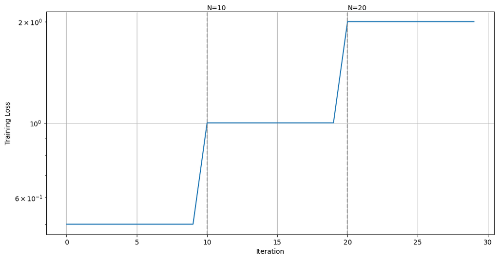

```
All visible tests passed!
```

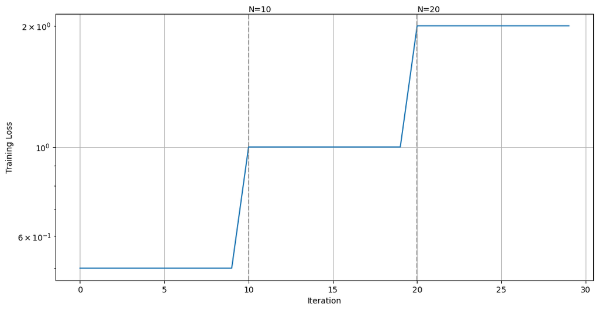

```
All visible tests passed!
```

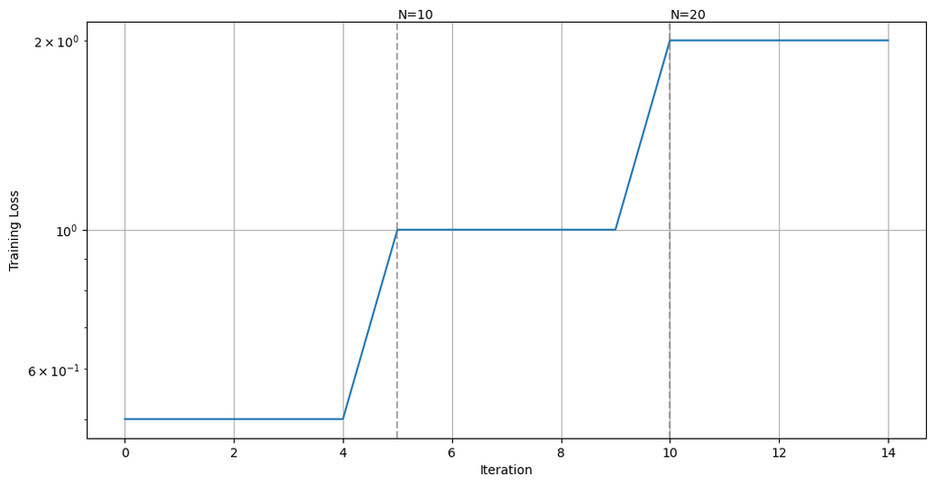

```
Training procedure tests passed!
```

```python
def test_train_and_visualize_model_instability_return_values():
    """Test that the function returns the expected types and structure."""
    # Setup a simple mock model
    class MockModel:
        def __init__(self):
            self.params = [torch.nn.Parameter(torch.randn(2, 2))]

        def parameters(self):
            return self.params

        def compute_loss(self, data, times):
            # Mock loss that depends on sequence length to simulate NODE instability
            # Longer sequences produce higher loss values
            return torch.tensor(0.1 * len(data), requires_grad=True)

    model = MockModel()
    data = torch.randn(20, 3)  # 20 time steps, 3 dimensions
    times = torch.linspace(0, 1, 20)

    # Call function with small number of iterations for testing
    all_losses, seq_lengths, cumulative_iterations = train_and_visualize_model_instability(
        model, data, times, iterations_per_length=10, initial_length=5, print_every=5, visualize=False
    )

    # Check return types
    assert isinstance(all_losses, list), "all_losses should be a list"
    assert isinstance(seq_lengths, list), "seq_lengths should be a list"
    assert isinstance(cumulative_iterations, list), "cumulative_iterations should be a list"

    # Check that lengths match expectations
    assert len(seq_lengths) > 0, "seq_lengths should not be empty"
    assert len(all_losses) == len(cumulative_iterations), "all_losses and cumulative_iterations should have the same length"

    # Check sequence length progression (doubles each time)
    for i in range(1, len(seq_lengths)):
        assert seq_lengths[i] == seq_lengths[i-1] * 2, "Sequence length should double each time"

    # Check that we have the correct number of losses for each sequence length
    iterations_per_length = 10
    assert len(all_losses) == iterations_per_length * len(seq_lengths), "Should have iterations_per_length losses for each sequence length"

    print("All visible tests passed!")

test_train_and_visualize_model_instability_return_values()

### BEGIN HIDDEN TESTS

def test_train_and_visualize_model_instability_return_values():
    """Test that the function returns the expected types and structure."""
    # Setup a simple mock model
    class MockModel:
        def __init__(self):
            self.params = [torch.nn.Parameter(torch.randn(2, 2))]

        def parameters(self):
            return self.params

        def compute_loss(self, data, times):
            # Mock loss that depends on sequence length to simulate NODE instability
            # Longer sequences produce higher loss values
            return torch.tensor(0.1 * len(data), requires_grad=True)

    model = MockModel()
    data = torch.randn(20, 3)  # 20 time steps, 3 dimensions
    times = torch.linspace(0, 1, 20)

    # Call function with small number of iterations for testing
    all_losses, seq_lengths, cumulative_iterations = train_and_visualize_model_instability(
        model, data, times, iterations_per_length=10, initial_length=5, print_every=5, visualize=False
    )

    # Check return types
    assert isinstance(all_losses, list), "all_losses should be a list"
    assert isinstance(seq_lengths, list), "seq_lengths should be a list"
    assert isinstance(cumulative_iterations, list), "cumulative_iterations should be a list"

    # Check that lengths match expectations
    assert len(seq_lengths) > 0, "seq_lengths should not be empty"
    assert len(all_losses) == len(cumulative_iterations), "all_losses and cumulative_iterations should have the same length"

    # Check sequence length progression (doubles each time)
    for i in range(1, len(seq_lengths)):
        assert seq_lengths[i] == seq_lengths[i-1] * 2, "Sequence length should double each time"

    # Check that we have the correct number of losses for each sequence length
    iterations_per_length = 10
    assert len(all_losses) == iterations_per_length * len(seq_lengths), "Should have iterations_per_length losses for each sequence length"

    print("All visible tests passed!")

test_train_and_visualize_model_instability_return_values()

def test_training_procedure_visible():
    """Test that the function executes training steps correctly."""
    class TrackingModel:
        def __init__(self):
            self.linear = torch.nn.Linear(3, 1)
            self.params = list(self.linear.parameters())
            self.compute_loss_called = 0

        def parameters(self):
            return self.params

        def compute_loss(self, data, times):
            # Track number of calls
            self.compute_loss_called += 1
            # Return loss based on sequence length
            return torch.tensor(0.1 * len(data), requires_grad=True)

    # Create model and data
    model = TrackingModel()
    data = torch.randn(20, 3)
    times = torch.linspace(0, 1, 20)

    # Run with minimal iterations for testing
    iterations_per_length = 5
    initial_length = 5

    train_and_visualize_model_instability(
        model, data, times,
        iterations_per_length=iterations_per_length,
        initial_length=initial_length,
        visualize=False
    )

    # Calculate how many iterations should have been performed
    expected_seq_lengths = [5, 10, 20]  # Starting with 5, doubling until we hit max of 20
    expected_calls = iterations_per_length * len(expected_seq_lengths)

    # Check that the model was called the correct number of times
    assert model.compute_loss_called == expected_calls, f"compute_loss should be called {expected_calls} times"

    print("Training procedure tests passed!")
test_training_procedure_visible()
### END HIDDEN TESTS
```

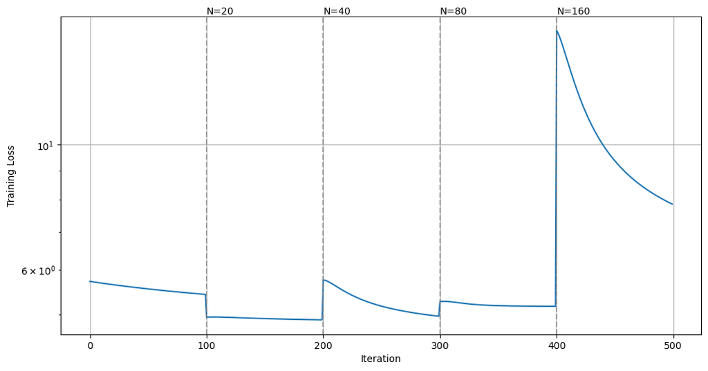

```python
model = LatentNode(latent_dim=1)
_ = train_and_visualize_model_instability(model,
                                          data,
                                          times,
                                          iterations_per_length=100,
                                          initial_length=10,
                                          print_every=10,
                                          visualize=False)
```

## Deriving Bayesian multiple shooting (2 points)

1. Write the posterior distribution $p(\theta_{dyn}, \theta_{dec}, s_{1:B} \mid y_{1:N})$ of the model using Bayesian multiple shooting as presented in the paper. Then explain how amortized inference is implemented to approximate this posterior, including:
- The structure of the variational distribution $q(\theta_{dyn}, \theta_{dec}, s_{1:B})$
- The role of the encoder hθenc in amortization
- How this enables efficient parallel computation across shooting blocks
2. Derive the ELBO loss used to train the multiple shooting model by:
- Starting with the general variational objective
- Expanding it to show all components (data likelihood, continuity prior, parameter priors)
- Explaining how each term in the ELBO contributes to the model (especially highlighting how the continuity prior terms enforce trajectory smoothness)

**Comments:**

No response.

[figure not shown]

## Latent Node with Multiple Shooting (3 points)

Implement the Neural ODE class with Bayesian sparse multiple shooting as described in the paper. Focus on these key components:

1. Define shooting variables as stochastic latent variables with appropriate distributions.
2. Partition the trajectory into a configurable number of blocks (num_blocks), creating efficient sub-trajectories.
3. For each block, compute the trajectory segment by integrating the dynamics function from the corresponding shooting variable.
4. Construct the ELBO loss with three essential terms: Reconstruction loss (data likelihood), KL divergence for the first shooting variable (initial state prior), Continuity KL divergence (enforcing smoothness between blocks)

When trained properly, this model should demonstrate stable convergence across increasing sequence lengths, unlike the standard Neural ODE implementation. Note that the loss scale is much larger here than the MSE loss, as long as the pattern shows clear decrease your implementation should be correct.

**Student's answer(Top)**

```python
# Multiple shooting version of the LatentNODE model with Sparse Bayesian approach
class MSLatentNODE(nn.Module):
    def __init__(self, latent_dim=2, num_blocks=5):
        """
        Multiple shooting version of the LatentNODE model with Sparse Bayesian approach.

        Args:
            latent_dim: Dimension of the latent space (per coordinate)
            num_blocks: Number of shooting blocks to use
        """
        super().__init__()
        self.latent_dim = latent_dim * 2  # x2 for position and velocity
        self.num_blocks = num_blocks
        # YOUR CODE HERE
        self.dynamics_func = DynamicsFunction(self.latent_dim)
        self.func_wrapper = nn.Module()
        self.func_wrapper.forward = lambda t,x : self.dynamics_func(x.unsqueeze(0)).squeeze(0)
        self.shooting_means = nn.ParameterList([nn.Parameter(torch.zeros(self.latent_dim)) for _ in range(self.num_blocks)])
        self.shooting_log_stds = nn.ParameterList([nn.Parameter(torch.zeros(self.latent_dim)) for _ in range(self.num_blocks)])

        self.shooting_means[0].data[:latent_dim] = torch.tensor(np.pi / 2.0)  # Angle = 90 degrees
        self.shooting_means[0].data[latent_dim:] = torch.tensor(0.0)          # Velocity = 0

        self.sigma = 0.1
        self.sigma_c = 0.01


        #raise NotImplementedError()

    def sample_shooting_vars(self):
        """
        Sample shooting variables from their variational distributions.
        This implements the reparameterization trick for backpropagation.
        """
        shooting_vars = []
        # YOUR CODE HERE
        for mean, log_std in zip(self.shooting_means, self.shooting_log_stds):
            std = torch.exp(log_std)
            eps = torch.randn_like(std)
            s_b = mean + eps*std
            shooting_vars.append(s_b)

        #raise NotImplementedError()
        return shooting_vars

    def forward(self, times):
        """
        Forward pass using multiple shooting with sampled shooting variables.

        Args:
            times: Time points for evaluation

        Returns:
            Complete trajectory by stitching together sub-trajectories
        """
        # YOUR CODE HERE
        self.shooting_vars = self.sample_shooting_vars()
        bounds = self._get_block_boundaries(times)
        segments = []
        for b, (s, e) in enumerate(bounds):
            t_span = times[s:e]
            init = self.shooting_vars[b]
            seg = odeint(self.func_wrapper, init, t_span)
            segments.append(seg)
        return torch.cat(segments, dim=0).unsqueeze(1)
        #raise NotImplementedError()

    def _get_block_boundaries(self, times):
        """
        Determine the start and end indices for each block.
        Creates blocks with approximately equal size by default.
        """
        # YOUR CODE HERE
        N = times.shape[0]
        size = N // self.num_blocks
        bounds = []
        for b in range(self.num_blocks):
            start = b * size
            end = (b+1)*size if b < self.num_blocks-1 else N
            bounds.append((start, end))
        return bounds
        #raise NotImplementedError()

    def compute_continuity_kl_divergence(self, times):
        """
        Compute KL divergence for the continuity prior as in the paper.
        This is one of the key innovations in the paper's approach.
        """
        # YOUR CODE HERE
        kl_sum = 0.0
        bounds = self._get_block_boundaries(times)
        for b in range(1, self.num_blocks):

            prev_start, prev_end = bounds[b-1]
            t0 = times[prev_start]
            t1 = times[prev_end] if prev_end < len(times) else times[-1]
            x_prev = self.shooting_vars[b-1]
            pred = odeint(self.func_wrapper, x_prev, torch.stack([t0, t1]))[-1]

            mu_q = self.shooting_means[b]
            std_q = torch.exp(self.shooting_log_stds[b])

            mu_p = pred.detach()
            std_p = torch.full_like(std_q, self.sigma_c)


            kl = (torch.log(std_p) - torch.log(std_q)
                  + (std_q.pow(2) + (mu_q - mu_p).pow(2)) / (2 * std_p.pow(2))
                  - 0.5).sum()
            kl_sum = kl_sum + kl
        return kl_sum
        #raise NotImplementedError()

    def compute_loss(self, y_true, times):
        """
        Compute total loss following the paper's ELBO formulation:
        ELBO = reconstruction term - KL divergence terms

        Args:
            y_true: Ground truth trajectory
            times: Time points

        Returns:
            Negative ELBO (loss to minimize)
        """
        # YOUR CODE HERE
        z = self.forward(times)

        recon = ((z - y_true).pow(2)).sum() / (2 * self.sigma**2)

        mu0 = self.shooting_means[0]
        std0 = torch.exp(self.shooting_log_stds[0])
        mu_p0 = torch.zeros_like(mu0)
        std_p0 = torch.full_like(std0, self.sigma)
        kl0 = (torch.log(std_p0) - torch.log(std0)
               + (std0.pow(2) + (mu0 - mu_p0).pow(2)) / (2 * std_p0.pow(2))
               - 0.5).sum()

        kl_cont = self.compute_continuity_kl_divergence(times)
        return recon + kl0 + kl_cont

        #raise NotImplementedError()
```

```python
def test_mslatentnode_initialization():
    """Test that the MSLatentNODE model initializes correctly."""
    # Create model with default parameters
    latent_dim = 2
    num_blocks = 5
    model = MSLatentNODE(latent_dim=latent_dim, num_blocks=num_blocks)

    # Check model attributes
    assert model.latent_dim == latent_dim * 2, "Latent dimension should be doubled for position and velocity"
    assert model.num_blocks == num_blocks, "Number of blocks should match input"

    # Check that shooting variables are initialized
    assert len(model.shooting_means) == num_blocks, "There should be one mean parameter per block"
    assert len(model.shooting_log_stds) == num_blocks, "There should be one log_std parameter per block"

    # Check that first shooting variable is initialized to pendulum initial conditions
    assert abs(model.shooting_means[0][0].item() - (np.pi/2.0)) < 1e-5, "First shooting mean should be initialized to π/2 (90 degrees)"
    assert abs(model.shooting_means[0][latent_dim].item()) < 1e-5, "First shooting velocity should be initialized to 0"

    print("Initialization test passed!")

test_mslatentnode_initialization()

def test_mslatentnode_block_boundaries():
    """Test that block boundaries are correctly calculated."""
    model = MSLatentNODE(latent_dim=2, num_blocks=3)
    times = torch.linspace(0, 1, 10)

    # Get block boundaries
    boundaries = model._get_block_boundaries(times)

    # Check that we have the correct number of boundaries
    assert len(boundaries) == 3, "Should have 3 boundary pairs for 3 blocks"

    # Check that the boundaries cover the entire range
    assert boundaries[0][0] == 0, "First block should start at index 0"
    assert boundaries[-1][1] == len(times), "Last block should end at the last time point"

    # Check that blocks are contiguous
    for i in range(len(boundaries)-1):
        assert boundaries[i][1] == boundaries[i+1][0], "Blocks should be contiguous"

    print("Block boundaries test passed!")

test_mslatentnode_block_boundaries()

def test_mslatentnode_forward():
    """Test that the forward pass produces output of the correct shape."""
    latent_dim = 2
    num_blocks = 3
    model = MSLatentNODE(latent_dim=latent_dim, num_blocks=num_blocks)

    # Create some time points
    times = torch.linspace(0, 1, 20)

    # Run forward pass
    trajectory = model(times)

    # Check output shape
    expected_shape = (len(times), 1, latent_dim * 2)  # (time, batch, features)
    assert trajectory.shape == expected_shape, f"Expected shape {expected_shape}, got {trajectory.shape}"

    print("Forward pass test passed!")

test_mslatentnode_forward()


### BEGIN HIDDEN TESTS
def test_mslatentnode_initialization():
    """Test that the MSLatentNODE model initializes correctly."""
    # Create model with default parameters
    latent_dim = 2
    num_blocks = 5
    model = MSLatentNODE(latent_dim=latent_dim, num_blocks=num_blocks)

    # Check model attributes
    assert model.latent_dim == latent_dim * 2, "Latent dimension should be doubled for position and velocity"
    assert model.num_blocks == num_blocks, "Number of blocks should match input"

    # Check that shooting variables are initialized
    assert len(model.shooting_means) == num_blocks, "There should be one mean parameter per block"
    assert len(model.shooting_log_stds) == num_blocks, "There should be one log_std parameter per block"

    # Check that first shooting variable is initialized to pendulum initial conditions
    assert abs(model.shooting_means[0][0].item() - (np.pi/2.0)) < 1e-5, "First shooting mean should be initialized to π/2 (90 degrees)"
    assert abs(model.shooting_means[0][latent_dim].item()) < 1e-5, "First shooting velocity should be initialized to 0"

    print("Initialization test passed!")

test_mslatentnode_initialization()

def test_mslatentnode_block_boundaries():
    """Test that block boundaries are correctly calculated."""
    model = MSLatentNODE(latent_dim=2, num_blocks=3)
    times = torch.linspace(0, 1, 10)

    # Get block boundaries
    boundaries = model._get_block_boundaries(times)

    # Check that we have the correct number of boundaries
    assert len(boundaries) == 3, "Should have 3 boundary pairs for 3 blocks"

    # Check that the boundaries cover the entire range
    assert boundaries[0][0] == 0, "First block should start at index 0"
    assert boundaries[-1][1] == len(times), "Last block should end at the last time point"

    # Check that blocks are contiguous
    for i in range(len(boundaries)-1):
        assert boundaries[i][1] == boundaries[i+1][0], "Blocks should be contiguous"

    print("Block boundaries test passed!")

test_mslatentnode_block_boundaries()

def test_mslatentnode_forward():
    """Test that the forward pass produces output of the correct shape."""
    latent_dim = 2
    num_blocks = 3
    model = MSLatentNODE(latent_dim=latent_dim, num_blocks=num_blocks)

    # Create some time points
    times = torch.linspace(0, 1, 20)

    # Run forward pass
    trajectory = model(times)

    # Check output shape
    expected_shape = (len(times), 1, latent_dim * 2)  # (time, batch, features)
    assert trajectory.shape == expected_shape, f"Expected shape {expected_shape}, got {trajectory.shape}"

    print("Forward pass test passed!")

test_mslatentnode_forward()

def test_hidden_sampling_mechanism():
    """Test that the sampling of shooting variables follows the reparameterization trick."""
    torch.manual_seed(42)  # Fix seed for reproducibility

    model = MSLatentNODE(latent_dim=2, num_blocks=3)

    # Save original parameters
    original_means = [m.clone().detach() for m in model.shooting_means]
    original_log_stds = [ls.clone().detach() for ls in model.shooting_log_stds]

    # Sample shooting variables
    shooting_vars = model.sample_shooting_vars()

    # Check number of variables
    assert len(shooting_vars) == 3, "Should sample one variable per block"

    # Check shape of each variable
    for var in shooting_vars:
        assert var.shape == torch.Size([4]), "Each variable should have shape (latent_dim*2)"
```

```python
    # Verify reparameterization: sample again and check difference
    torch.manual_seed(43)  # Different seed
    new_shooting_vars = model.sample_shooting_vars()

    # Check that samples are different (reparameterization is working)
    differences = [torch.norm(v1 - v2).item() for v1, v2 in zip(shooting_vars, new_shooting_vars)]
    assert all(diff > 1e-4 for diff in differences), "Samples should differ with different random seeds"

test_hidden_sampling_mechanism()

def test_hidden_compute_loss_breakdown():
    """Test the loss computation by checking each component separately."""
    model = MSLatentNODE(latent_dim=1, num_blocks=2)
    times = torch.linspace(0, 1, 10)
    y_true = torch.sin(times).unsqueeze(-1).unsqueeze(-1) * 2  # Simple sine curve

    # Override forward and compute_continuity_kl_divergence to return known values
    original_forward = model.forward
    original_kl = model.compute_continuity_kl_divergence

    def mock_forward(times):
        return torch.sin(times).unsqueeze(-1).unsqueeze(-1) * 2.1  # Slightly off prediction

    def mock_kl(times):
        return torch.tensor(0.5)  # Fixed KL value

    model.forward = mock_forward
    model.compute_continuity_kl_divergence = mock_kl

    try:
        # Set known values for first shooting variable
        with torch.no_grad():
            model.shooting_means[0].fill_(0.3)
            model.shooting_log_stds[0].fill_(-2.0)

        # Compute loss
        loss = model.compute_loss(y_true, times)

        # Calculate expected components:
        # 1. Reconstruction loss: MSE between y_true and y_pred
        y_pred = mock_forward(times)
        expected_recon_loss = torch.mean((y_pred[...,0] - y_true[...,0])**2)

        # 2. Continuity KL
        expected_continuity_kl = torch.tensor(0.5)  # From mock function

        # 3. KL for first shooting variable
        mean_first = torch.ones(2) * 0.3
        log_std_first = torch.ones(2) * -2.0
        var_first = torch.exp(2 * log_std_first)
        expected_kl_first = 0.5 * torch.sum(
            var_first + mean_first**2 - 1 - torch.log(var_first)
        )

        # Total expected loss
        expected_loss = expected_recon_loss + expected_continuity_kl + expected_kl_first

        # Check if computed loss matches expected
        assert abs(loss.item() - expected_loss.item()) < 1e-5, "Loss computation doesn't match expected result"

    finally:
        # Restore original methods
        model.forward = original_forward
        model.compute_continuity_kl_divergence = original_kl

test_hidden_compute_loss_breakdown()

def test_hidden_shooting_variables_gradient():
    """Test that gradients flow through the shooting variables correctly."""
    model = MSLatentNODE(latent_dim=1, num_blocks=2)
    optimizer = torch.optim.Adam(model.parameters(), lr=0.01)
    times = torch.linspace(0, 1, 10)
    y_true = torch.sin(times).unsqueeze(-1).unsqueeze(-1) * 2

    # Store initial parameters
    initial_means = [p.clone().detach() for p in model.shooting_means]
    initial_log_stds = [p.clone().detach() for p in model.shooting_log_stds]

    # Override forward and KL to simplify test
    original_forward = model.forward
    original_kl = model.compute_continuity_kl_divergence

    def mock_forward(times):
        shooting_vars = model.sample_shooting_vars()
        # Simple function of shooting variables
        result = torch.zeros_like(y_true)
        for i, var in enumerate(shooting_vars):
            indices = slice(i*5, (i+1)*5) if i < len(shooting_vars)-1 else slice(i*5, None)
            if indices.stop is not None and indices.stop <= result.shape[0]:
                result[indices] = var.mean().expand_as(result[indices])
        return result

    def mock_kl(times):
        return sum(torch.sum(var**2) for var in model.shooting_means) * 0.1

    model.forward = mock_forward
    model.compute_continuity_kl_divergence = mock_kl

    try:
        # Train for a few steps
        for _ in range(5):
            optimizer.zero_grad()
            loss = model.compute_loss(y_true, times)
            loss.backward()
            optimizer.step()

        # Check that parameters have changed
        final_means = [p.clone().detach() for p in model.shooting_means]
        final_log_stds = [p.clone().detach() for p in model.shooting_log_stds]

        mean_changes = [torch.norm(f - i).item() for f, i in zip(final_means, initial_means)]
        log_std_changes = [torch.norm(f - i).item() for f, i in zip(final_log_stds, initial_log_stds)]

        # Verify that at least some parameters have significant changes
        assert any(change > 1e-4 for change in mean_changes), "Shooting means did not change during training"
        assert any(change > 1e-4 for change in log_std_changes), "Shooting log_stds did not change during training"

    finally:
        # Restore original methods
        model.forward = original_forward
        model.compute_continuity_kl_divergence = original_kl

test_hidden_shooting_variables_gradient()

def test_hidden_full_integration():
    """Test the complete model with actual ODE integration."""
    # Import needed modules
    from torchdiffeq import odeint

    # Define a simple dynamics function for testing
    class SimpleDynamicsFunction(nn.Module):
        def __init__(self, dim):
            super().__init__()
            self.net = nn.Sequential(
                nn.Linear(dim, 10),
                nn.Tanh(),
                nn.Linear(10, dim)
            )

        def forward(self, x):
            return self.net(x)

    # Create a custom MSLatentNODE with simpler dynamics
    class TestMSLatentNODE(MSLatentNODE):
        def __init__(self, latent_dim=1, num_blocks=2):
            super().__init__(latent_dim, num_blocks)
            # Override dynamics function with simpler one
            self.dynamics_func = SimpleDynamicsFunction(self.latent_dim)

    # Create model and test data
    model = TestMSLatentNODE(latent_dim=1, num_blocks=2)
    times = torch.linspace(0, 1, 10)
    y_true = torch.sin(times).unsqueeze(-1).unsqueeze(-1) * 2
```

```python
    # Run forward pass
    trajectory = model(times)

    # Verify shape
    assert trajectory[...,0].shape == y_true[...,0].shape, f"Expected shape {y_true.shape}, got {trajectory.shape}"

    # Compute loss
    loss = model.compute_loss(y_true, times)

    # Verify loss is a scalar and requires gradient
    assert loss.dim() == 0, "Loss should be a scalar"
    assert loss.requires_grad, "Loss should require gradient"

    # Check gradient flow
    loss.backward()

    # Verify all parameters have gradients
    for p in model.parameters():
        assert p.grad is not None, "All parameters should have gradients"
        assert torch.norm(p.grad) > 0, "Gradients should be non-zero"

test_hidden_full_integration()
### END HIDDEN TESTS
```

```
Initialization test passed!
Block boundaries test passed!
Forward pass test passed!
Initialization test passed!
Block boundaries test passed!
Forward pass test passed!
```

```
---------------------------------------------------------------------------
AssertionError                            Traceback (most recent call last)
Cell In[14], line 220
    217         model.forward = original_forward
    218         model.compute_continuity_kl_divergence = original_kl
--> 220 test_hidden_compute_loss_breakdown()
    222 def test_hidden_shooting_variables_gradient():
    223     """Test that gradients flow through the shooting variables correctly."""

Cell In[14], line 213, in test_hidden_compute_loss_breakdown()
    210     expected_loss = expected_recon_loss + expected_continuity_kl + expected_kl_first
    212     # Check if computed loss matches expected
--> 213     assert abs(loss.item() - expected_loss.item()) < 1e-5, "Loss computation doesn't match expected result"
    215 finally:
    216     # Restore original methods
    217     model.forward = original_forward

AssertionError: Loss computation doesn't match expected result
```

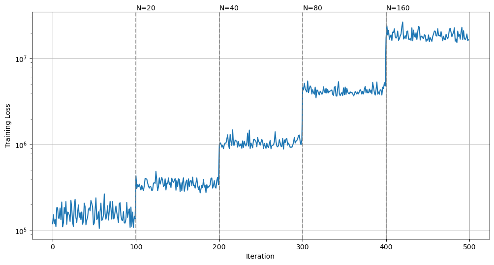

```python
model = MSLatentNODE(latent_dim=1)
_ = train_and_visualize_model_instability(model,
                                          data,
                                          times,
                                          iterations_per_length=100,
                                          initial_length=10,
                                          print_every=10,
                                          visualize=False)
```